# Pełnoletnie dzieci mieszkające z rodzicami

Agata Czajkowska

9 października 2017

> Źródło danych

Jako żródło danych posłużył mi artykuł opracowany przez p.Rafała Boguszewskiego i p.Mariolę Piszczatowską-Oleksiewicz będący podsumowaniem badań CBOSu dotyczących pełnoletnich Polaków stanu wolnego mieszkających z rodzicami (http://www.cbos.pl/SPISKOM.POL/2017/K_098_17.PDF). W artykule autorzy zawarli przedstawione przeze mnie dane w postaci tabelarycznej.

> Procent Polaków mieszkających z rodzicami w zależności od wielkości rodzinnego miasta
1. Orginalne przedstawienie danych

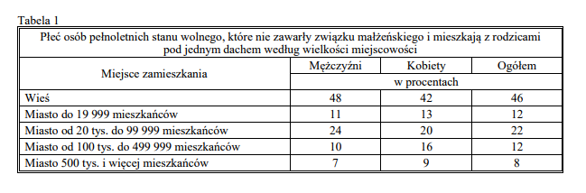

2. Wizualizacja

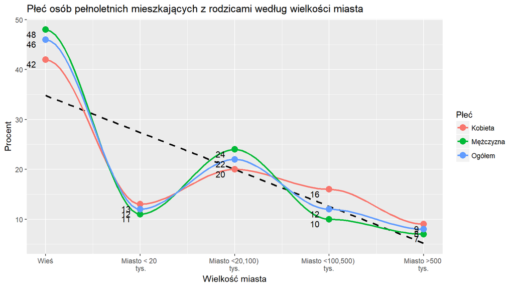

Można zauważyć ogólną tendencję,że im większe jest rodzinne miasto tym mniej młodych dorosłych Polaków mieszka z rodzicami/opiekunami. Największe różnice jeśli chodzi o kobiet i mężczyzn pozostających w rodzinnych domach można zauważyć na wsiach i w miastach zaludnieniu od <100,500) tysięcy mieszkańców. Na wsiach w domach pozostaje więcej mężczyzn w miastach od <100,500) tysięcy mieszkańców więcej kobiet.

> Przynależność do grup społeczno-zawodowych pełnoletnich Polaków mieszkających z rodzicami
1. Orginalne przedstawienie danych

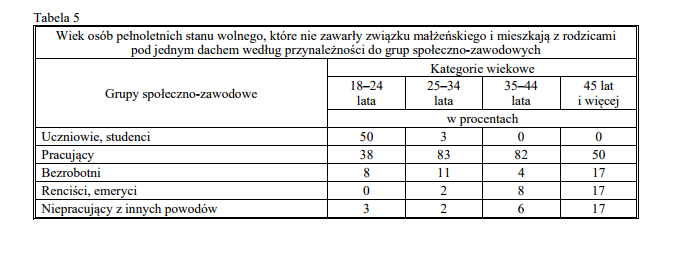

2. Wizualizacja

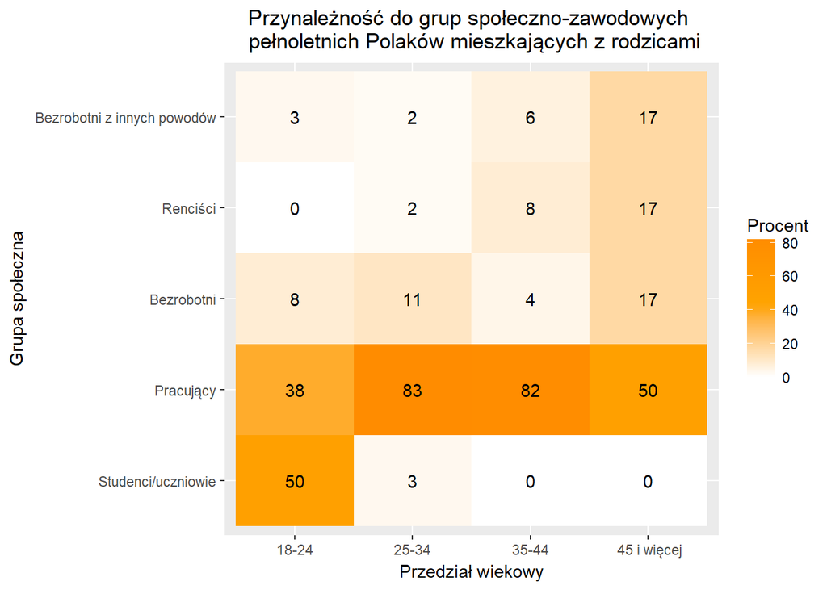

Najwięcej osób w przedziale wiekowym od 18-24 lat mieszkających z rodzicami to studenci/uczniowie , 12% mniej stanowią osoby pracujące.Pozostałe grupy społeczne stanowią mniejszość w tej grupie wiekowej. W przedziałach 25-34,35-44 lat z osób mieszkających w rodzinnym domu odpowiednio 83 i 82 procent to osoby pracujące. Wtych przedziałach pozostałe grupy społeczne stanowią wyraźną mniejszość. Wśród najstarszej grupy Plaków mieszkających z rodzicami polowa to osoby pracujące , reszta rozkłada się po równo (17%) między grupy bezrobotnych, renscistów i bezrobotnych z innych powodów.

> Niezależnośc finansowa osób mieszkających z rodzicami w kontekście przynależności do grupy społeczno-zawodowej
1. Orginalne przedstawienie danych

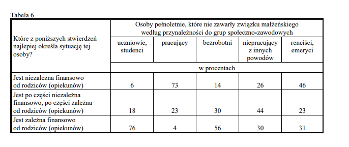

2. Wizualizacja

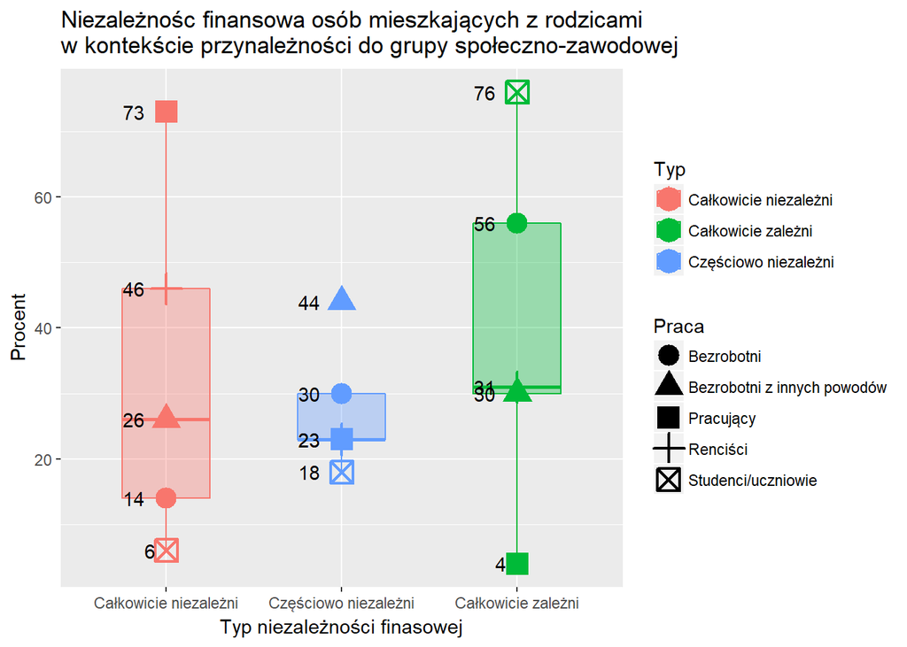

Różnice między przynależnością do grupy społecznej a niezależnością finansową wśród osób mieszkających w rodzinnym domu są znacznie większe zarówno w przypadku pełnej zależności jak i pełniej nezależności finansowej niż częściowej niezależności finansowej. Osoby całkowicie zależne finansowo od rodziców to przede wszystkim studenci i osoby bezrobotne. Osoby niezależne finansowo to przede wszystkim osoby pracujące i renciści.